# Beijing traffic flow

All-lane traffic flow from simulation day 10 on 11,742 directed road edges. The full day has 288 five-minute frames, in vehicles/hour.

## Interactive map

LayersRoadsEventsBasemapRoad casing

Region

Event category

Time

[interactive chart not shown]

Mean of finite road values

[interactive chart not shown]

Events by reported start interval

Statistics cover the selected records, including locations outside the current view. Times and units retain their supplied meanings.

## Summary

### All records

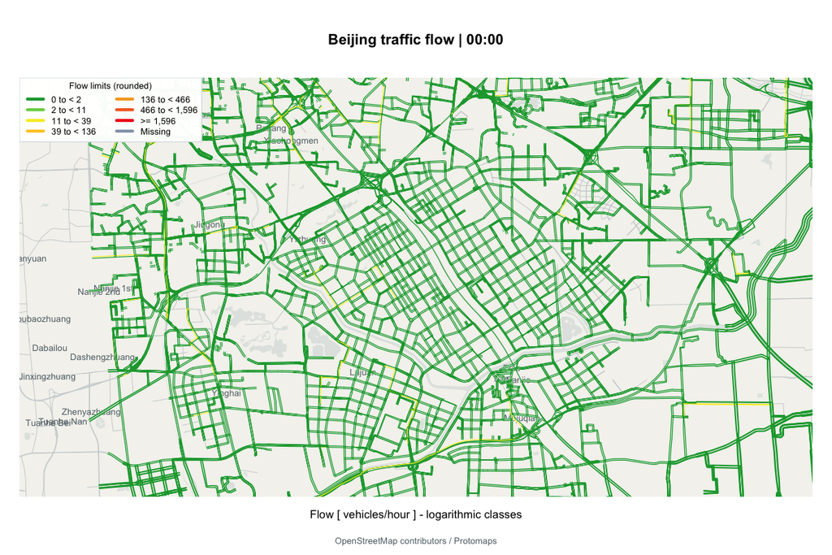

#### Flow trend

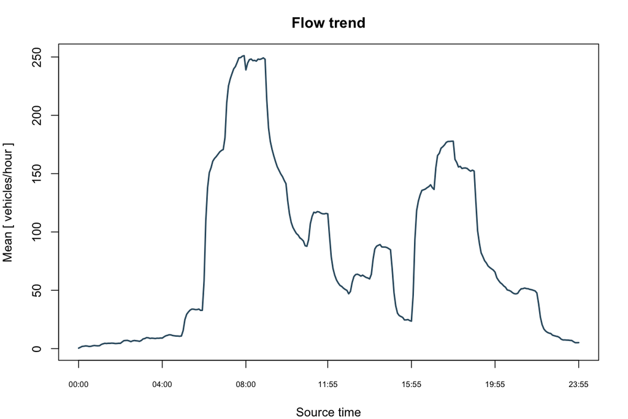

Dataset

| frames | roads | events | first_time |
| --- | --- | --- | --- |
| 288 | 11,742 | 0 | 00:00 |

Displayed interval

| frame | time | roads | events |
| --- | --- | --- | --- |
| 1 | 00:00 | 11,742 | 0 |

Flow availability

| available | missing | zero |
| --- | --- | --- |
| 11,742 | 0 | 11,389 |

Flow distribution

| minimum | median | mean | p95 | maximum |
| --- | --- | --- | --- | --- |
| 0 | 0 | 0.414921 | 0 | 36 |

Statistics cover all input records. Means and distributions use finite road values; missing observations are counted separately. Reported events are counted by start interval. Road-value sums are not interpreted as distinct vehicle counts.

## Preparation

The simulation road statistics in output_LinkTDMOE.csv provide link_volume_in_veh_per_hour_for_all_lanes, an all-lane hourly flow rate reported each minute. The directed node pair identifies the road.

For each five-minute frame within [0, 1440) source minutes, the five minute-level rates are averaged. This equals twelve times the five-minute entry count. Each retained road has all 1,440 minute records, with no duplicate road-minute keys. The mean rate is stored in the common road_id, time and flow table.

Road geometry, frame times and the flow table share explicit road identifiers. Context geometry and source identities accompany the observations.

Offline context contains longitude/latitude geometry, optional Point captions in properties.label and a supplied attribution string.

The input contains road_id and longitude/latitude geometry, road_id, time and flow records, and optional event time, lon and lat records. Zero is observed; omitted road-time records and explicit NA are missing. Events belong to half-open frame intervals.

One green-to-red seven-color palette and one log1p algorithm apply to every flow input. Exact thresholds use the global maximum across all times and records and remain fixed during interaction; class labels are rounded for display.

```
library(bdynets)
x <- read_traffic("data/input.rds")
plot(x)
traffic_map(x, "map.html")
traffic_report(x, "report.html")
```

## Fields and scope

The source is a traffic simulation. Flow is the all-lane entry rate in vehicles/hour, averaged over each five-minute interval. It is not a field sensor measurement.

The supplied geometry covers 11,742 of the 12,287 directed node pairs in the source statistics. The retained 16,908,480 road-minute records cover all 3,381,696 road-frame cells. Zero is recorded flow; it does not indicate missing data.

Road attributes describe node endpoints, length, lanes, speed limit and link type. Flow alone does not establish congestion causes.

Units are supplied labels; an omitted unit is shown as unit unspecified. Values and source road coordinates are retained without inferred conversions. Geometry vertices follow travel direction. Optional opposite_id values declare reciprocal relationships between existing road IDs. Without a declaration, unique exact reverse paths or sustained mutual nearest geometry matches are used. Automatic matching uses reverse headings within 15 degrees, proximity within 30 ground metres, and at least 60 percent probe support per segment. Competing alternatives within 2 metres and substantial lateral side changes are ambiguous. Ambiguous records retain source geometry. Explicit partners still need overlapping reversed geometry. Descriptive attributes do not control pairing.

Every input opens at its first frame with all records selected. Region and category controls filter only after an explicit selection. Named region selections match provided labels exactly; unassigned records remain in the all-record scope. The report summarizes all records and shows each applicable flow and event trend.

Display offsets do not represent physical road positions. Existing separation contributes to the gap. Coincident paths use the right side of each directed path as a drawing convention; other paths move apart. Adjacent segment shifts are averaged at vertices. Line width, opposing edge gap and white casing adapt continuously to zoom and local visible road-length density. Panning, zooming and resizing recompute layout. Static figures use 1/96-inch graphics line-width units and interactive maps use pixels. Event locations remain as supplied.

Roads and events both contribute to geographic focus across the supplied times. Reset view uses the central spatial range; Full extent includes all road vertices and event locations in the selected scope. Unknown timezones, event durations and event-to-road assignments are not inferred.

Projected geometry and road bounds are cached. A spatial index limits layout and layer updates to the view plus its density margin. Offscreen layers are detached and reused; all records remain available to statistics, filters, time controls and Full extent. Unchanged views reuse layout and display coordinates. These caches create no additional files.

Roads, events, basemap and road casing have independent visibility controls. Controls are disabled for absent input components. Hiding roads also removes their casing. Layer visibility does not change statistics, record selection, time membership or geographic extents. Road and event popups retain their record information.

Optional context geometry uses one neutral style. Point captions use properties.label. Attribution is supplied with the context; an omitted source is shown as unspecified.

**Source identities**

```
{
  "source_file": "output_LinkTDMOE.csv",
  "source_sha256": "6c576e7dcecbc1e5e0c602e0409669f365d5dba383321cfccf5c7f180445abf8",
  "source_field": "link_volume_in_veh_per_hour_for_all_lanes",
  "day_no": 10,
  "geometry_source": "saturation_dynamic_leaflet_osm_osmgeom.html",
  "geometry_source_sha256": "62ea476665faf640f146b5998583e4418378ccc04788b30c3e1db9e4b81b8a4e"
}
```

Map context: OpenStreetMap contributors / Protomaps.

Leaflet is distributed under its included BSD license.